# Logistic Regression model (2)

## Burns data

```r
library(tidyverse)
library(aplore3)
d <- burn1000         # just to have shorter name for the dataframe
head(d)
```

```
  id facility death  age gender      race tbsa inh_inj flame
1  1       11 Alive 26.6   Male     White 25.3      No   Yes
2  2        1 Alive  2.0 Female Non-White  5.0      No    No
3  3       12 Alive 22.0 Female Non-White  2.0      No    No
4  4        1 Alive 37.3   Male     White  2.0      No    No
5  5        1 Alive 52.1   Male     White  6.0      No   Yes
6  6        6 Alive 50.2   Male     White  7.0      No    No
```

```r
mod_s <- glm(death ~ tbsa, data = d, family=binomial)
mod_i <- glm(death ~ inh_inj, data = d, family=binomial)
```

## A third model with two predictors

```r
mod_si <- glm(death ~ inh_inj + tbsa, data = d, family=binomial)
summary(mod_si)
```

```
Call:
glm(formula = death ~ inh_inj + tbsa, family = binomial, data = d)

Coefficients:
            Estimate Std. Error z value Pr(>|z|)
(Intercept) -3.37958    0.17760 -19.029  < 2e-16 ***
inh_injYes   1.28988    0.29258   4.409 1.04e-05 ***
tbsa         0.07291    0.00721  10.112  < 2e-16 ***
---
Signif. codes:  0 '***' 0.001 '**' 0.01 '*' 0.05 '.' 0.1 ' ' 1

(Dispersion parameter for binomial family taken to be 1)

    Null deviance: 845.42  on 999  degrees of freedom
Residual deviance: 520.73  on 997  degrees of freedom
AIC: 526.73

Number of Fisher Scoring iterations: 5
```

## Comparing nested models: Likelihood Ratio Test

Use `anova()` with option `test="LRT"`

```r
anova(mod_s, mod_si, test = "LRT")
```

```
Analysis of Deviance Table

Model 1: death ~ tbsa
Model 2: death ~ inh_inj + tbsa
  Resid. Df Resid. Dev Df Deviance  Pr(>Chi)
1       998     538.65
2       997     520.73  1    17.92 2.303e-05 ***
---
Signif. codes:  0 '***' 0.001 '**' 0.01 '*' 0.05 '.' 0.1 ' ' 1
```

Deviance is a measure of (lack of) fit: the lower, the better

AIC is similar, but penalizing model complexity: the lower the better

## The effect of inhalation injury

```r
exp(coef(mod_i)); exp(coef(mod_si))
```

```
(Intercept)  inh_injYes
    0.09750    14.76923
```

```
(Intercept)  inh_injYes        tbsa
 0.03406189  3.63233807  1.07563276
```

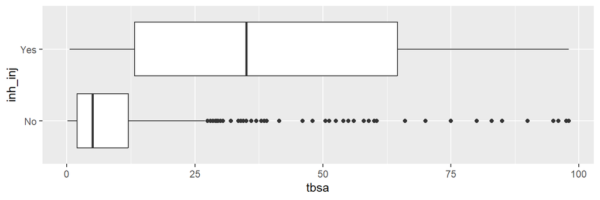

```r
library(ggformula)
gf_boxplot(tbsa ~ inh_inj, data=d) + coord_flip()
```

## Predicted values

```r
predict(mod_si) %>% head()       # gives the logits!
```

```
        1         2         3         4         5         6
-1.534976 -3.015030 -3.233758 -3.233758 -2.942121 -2.869212
```

to get predicted probabilities use argument `type="response"`

```r
predict(mod_si,  type = "response") %>% head()
```

```
         1          2          3          4          5          6
0.17726685 0.04675145 0.03791493 0.03791493 0.05011020 0.05369666
```

## Assumptions

1. Large sample: 10-25 events and non-events per *parameter* (not per variable!)
2. Linearity on the logit scale (numeric predictors)
3. No *influential* outliers
1. In the burns data, 150 deaths and 850 alive, so:
- Models with > 150/10 = 15 parameters are unreliable
- Models with \(\le\) 150/25 = 6 parameters are OK
- Models with 7-15 parameters, care

## Events per parameter

How many parameters are estimated in this model?

```r
mod <- glm(death ~ (inh_inj + flame) * (tbsa * age) + gender + race , data=d, family = binomial)
round(summary(mod)$coef,4)
```

```
                    Estimate Std. Error z value Pr(>|z|)
(Intercept)          -8.9460     1.7103 -5.2307   0.0000
inh_injYes            7.7683     1.8751  4.1429   0.0000
flameYes             -2.0285     2.1082 -0.9622   0.3359
tbsa                  0.0052     0.0752  0.0692   0.9448
age                   0.0988     0.0249  3.9701   0.0001
genderMale            0.0230     0.3361  0.0685   0.9454
raceWhite            -0.8067     0.3245 -2.4863   0.0129
tbsa:age              0.0019     0.0016  1.1842   0.2363
inh_injYes:tbsa      -0.0763     0.0481 -1.5870   0.1125
inh_injYes:age       -0.0837     0.0290 -2.8852   0.0039
flameYes:tbsa         0.1428     0.0808  1.7673   0.0772
flameYes:age          0.0286     0.0315  0.9069   0.3645
inh_injYes:tbsa:age  -0.0002     0.0009 -0.1772   0.8594
flameYes:tbsa:age    -0.0020     0.0017 -1.1543   0.2484
```

## A model with six variables

```r
m6v <- glm(death ~ tbsa + inh_inj + flame + age + gender + race ,
           data=d, family = binomial)
summary(m6v)
```

```
Call:
glm(formula = death ~ tbsa + inh_inj + flame + age + gender +
    race, family = binomial, data = d)

Coefficients:
             Estimate Std. Error z value Pr(>|z|)
(Intercept) -7.695153   0.691169 -11.134  < 2e-16 ***
tbsa         0.089345   0.009087   9.832  < 2e-16 ***
inh_injYes   1.365277   0.361780   3.774 0.000161 ***
flameYes     0.582578   0.354493   1.643 0.100298
age          0.082890   0.008629   9.606  < 2e-16 ***
genderMale  -0.201494   0.307784  -0.655 0.512687
raceWhite   -0.701389   0.309781  -2.264 0.023565 *
---
Signif. codes:  0 '***' 0.001 '**' 0.01 '*' 0.05 '.' 0.1 ' ' 1

(Dispersion parameter for binomial family taken to be 1)

    Null deviance: 845.42  on 999  degrees of freedom
Residual deviance: 336.46  on 993  degrees of freedom
AIC: 350.46

Number of Fisher Scoring iterations: 7
```

## Linearity on the logit scale

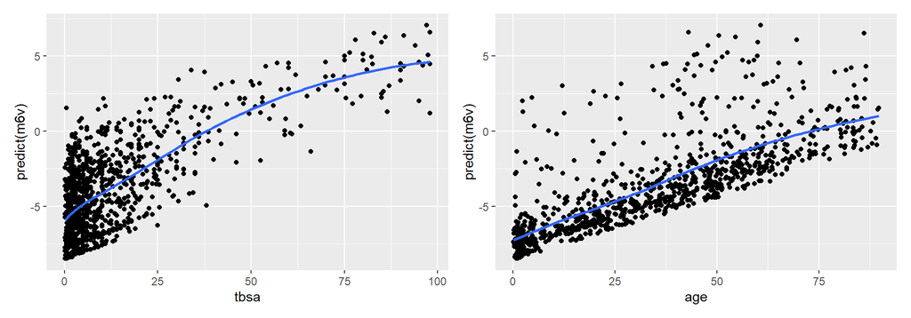

```r
library(patchwork)
plot1 <- gf_point(predict(m6v) ~ tbsa, data = d) %>% gf_smooth(method = "loess")
plot2 <- gf_point(predict(m6v) ~ age, data = d) %>% gf_smooth(method = "loess")
plot1 + plot2
```

## Influence measures

Cook’s distance, standardized residuals and leverages

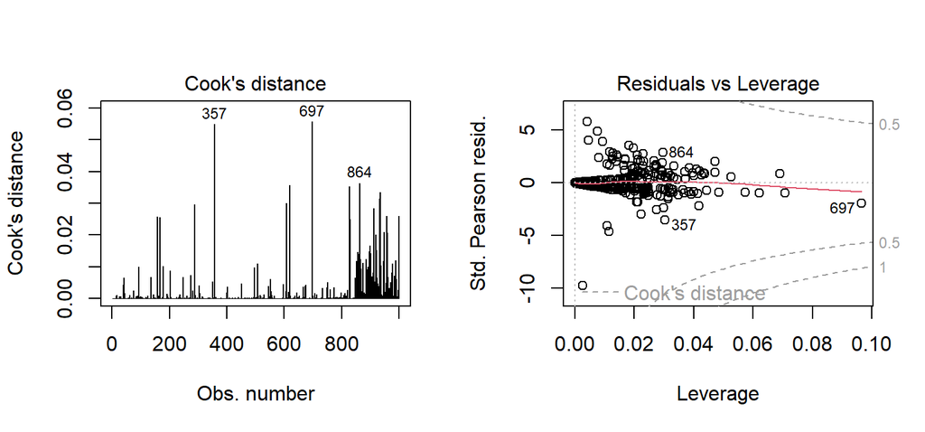

```r
par(mfrow = c(1,2))
plot(m6v,4)
plot(m6v,5)
```

## Exercise

1. Read the [Titanic data](https://raw.githubusercontent.com/acobos/Datasets/master/Mysterious_event.txt) as in the previous exercise and fit a model (`m2`) for `Survival` with `Class`, `Age` and `Sex` as predictors:
   - What is the class with the lowest survival probability, given sex and age?
   - What is the OR of survival for females compared to males, for any given combination of class and age?
   - Use a Likelihood Ratio Test to compare model `m2` to model `m1` fitted in the previous exercise (with only `Class` as predictor).
   - Is the fit of `m2` significantly better than that of `m1`?